# sparklyr installation

Yue You

2021-07-22

If you needed to sort large amounts of data, there was no other system in the world faster than Spark.

Officially, sparklyr is an R interface for Apache Spark. It’s available in CRAN and works like any other CRAN package, meaning that it’s agnostic to Spark versions, it’s easy to install, it serves the R community, it embraces other packages and practices from the R community, and so on.

[Book to master Spark with R.](https://therinspark.com/starting.html#overview)

[Cheat sheet available!!](https://ugoproto.github.io/ugo_r_doc/pdf/sparklyr.pdf)

## Installation

From R, getting started with Spark using sparklyr and a local cluster is as easy as installing and loading the sparklyr package followed by installing Spark using sparklyr.

The tools you’ll use are mostly divided into R code and the Spark web interface. All Spark operations are run from R; however, monitoring execution of distributed operations is performed from Spark’s web interface, which you can load from any web browser.

Additionally, because Spark is built in the Scala programming language, which is run by the Java Virtual Machine (JVM), you also need to install Java 8 on your system. It is likely that your system already has Java installed, but you should still check the version.

```r
system("java -version")
```

#### Install sparklyr

```r
#install.packages("sparklyr")
packageVersion("sparklyr")
```

```
## [1] '1.7.1'
```

#### Install Spark

```r
library(sparklyr)
spark_available_versions()
```

```
##   spark
## 1   1.6
## 2   2.0
## 3   2.1
## 4   2.2
## 5   2.3
## 6   2.4
## 7   3.0
## 8   3.1
```

```r
spark_install("3.1")   #you need to run this.
spark_installed_versions()
```

```
##   spark hadoop
## 1 3.1.1    2.7
## 2 3.1.1    3.2
##                                                                  dir
## 1 /mnt/student.unimelb.edu.au/yueyou/spark/spark-3.1.1-bin-hadoop2.7
## 2 /mnt/student.unimelb.edu.au/yueyou/spark/spark-3.1.1-bin-hadoop3.2
```

```r
#spark_uninstall(version = "2.3.3", hadoop = "2.7")
```

### Getiing started

#### Connecting

It’s important to mention that, so far, we’ve installed only a local Spark cluster. A local cluster is really helpful to get started, test code, and troubleshoot with ease.

```r
sc <- spark_connect(master = "local", version = "3.1")
```

After a connection is established, spark_connect() retrieves an active Spark connection, which most code usually names sc; you will then make use of sc to execute Spark commands.

#### Using Spark

Now that you are connected, we can run a few simple commands. For instance, let’s start by copying the mtcars dataset into Apache Spark by using copy_to():

```r
cars <- copy_to(sc, mtcars)
```

```r
cars
```

```
## # Source: spark<mtcars> [?? x 11]
##      mpg   cyl  disp    hp  drat    wt  qsec    vs    am  gear  carb
##    <dbl> <dbl> <dbl> <dbl> <dbl> <dbl> <dbl> <dbl> <dbl> <dbl> <dbl>
##  1  21       6  160    110  3.9   2.62  16.5     0     1     4     4
##  2  21       6  160    110  3.9   2.88  17.0     0     1     4     4
##  3  22.8     4  108     93  3.85  2.32  18.6     1     1     4     1
##  4  21.4     6  258    110  3.08  3.22  19.4     1     0     3     1
##  5  18.7     8  360    175  3.15  3.44  17.0     0     0     3     2
##  6  18.1     6  225    105  2.76  3.46  20.2     1     0     3     1
##  7  14.3     8  360    245  3.21  3.57  15.8     0     0     3     4
##  8  24.4     4  147.    62  3.69  3.19  20       1     0     4     2
##  9  22.8     4  141.    95  3.92  3.15  22.9     1     0     4     2
## 10  19.2     6  168.   123  3.92  3.44  18.3     1     0     4     4
## # … with more rows
```

```r
#read in csv file
taxi_tbl <- spark_read_csv(sc,
                           name = "taxi_data",
                           path ="../data/sample.csv",
                           header = TRUE, delimiter = ",")
```

```r
library(dplyr)
src_tbls(sc)
```

```
## [1] "mtcars"    "taxi_data"
```

Web Interface

```r
#spark_web(sc)
```

#### Analysis

In general, we usually start by analyzing data in Spark with dplyr, followed by sampling rows and selecting a subset of the available columns. The last step is to collect (collect() retrieves data into a local tibble.) data from Spark to perform further data processing in R, like data visualization. Let’s perform a very simple data analysis example by selecting, sampling, and plotting the cars dataset in Spark:

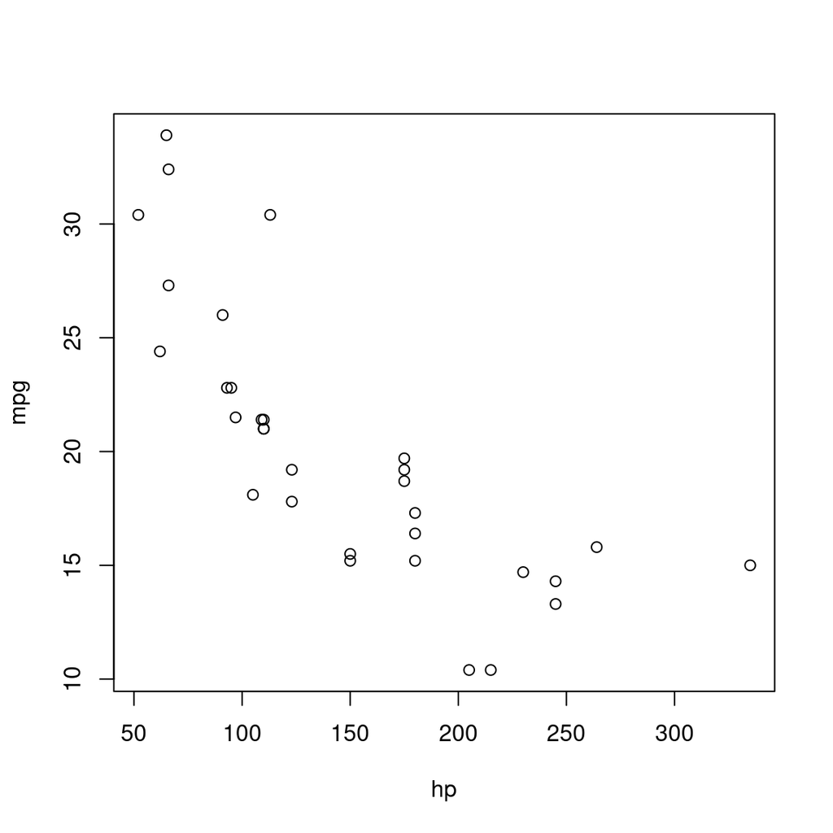

```r
library(tidyverse)
select(cars, hp, mpg) %>%
  sample_n(100) %>%
  collect() %>%
  plot()
```

#### Reading and writing data.

```r
#spark_write_csv(cars, "cars.csv")
#cars <- spark_read_csv(sc, "cars.csv")
```

#### Extensions.

For instance, the sparkly.nested extension is an R package that extends sparklyr to help you manage values that contain nested information.

```r
#install.packages("sparklyr.nested")
sparklyr.nested::sdf_nest(cars, hp) %>%
  group_by(cyl) %>%
  summarise(data = collect_list(data))
```

```
## # Source: spark<?> [?? x 2]
##     cyl data
##   <dbl> <list>
## 1     4 <list [11]>
## 2     8 <list [14]>
## 3     6 <list [7]>
```

Distributed R.

For those few cases when a particular functionality is not available in Spark and no extension has been developed, you can consider distributing your own R code across the Spark cluster.

```r
#cars %>% spark_apply(~round(.x))
```

#### Streaming

While processing large static datasets is the most typical use case for Spark, processing dynamic datasets in real time is also possible and, for some applications, a requirement. You can think of a streaming dataset as a static data source with new data arriving continuously, like stock market quotes. Streaming data is usually read from Kafka (an open source stream-processing software platform) or from distributed storage that receives new data continuously.

```r
#dir.create("input")
#write.csv(mtcars, "input/cars_1.csv", row.names = F)
```

Then, we define a stream that processes incoming data from the input/ folder, performs a custom transformation in R, and pushes the output into an output/ folder:

```r
#stream <- stream_read_csv(sc, "input/") %>%
    #select(mpg, cyl, disp) %>%
    #stream_write_csv("output/")

#stream_stop(stream)
```

#### Logs

A log is just a text file to which Spark appends information relevant to the execution of tasks in the cluster. For local clusters, we can retrieve all the recent logs by running the following:

```r
spark_log(sc)
```

[output not shown]

[output cut: 45 more lines]

[output not shown]

Or, we can retrieve specific log entries containing, say, sparklyr, by using the filter parameter, as follows:

```r
spark_log(sc, filter = "sparklyr")
```

```
## 21/07/22 11:58:16 INFO sparklyr: Session (82389) is starting under 127.0.0.1 port 8880
## 21/07/22 11:58:16 INFO sparklyr: Session (82389) found port 8880 is available
## 21/07/22 11:58:16 INFO sparklyr: Gateway (82389) is waiting for sparklyr client to connect to port 8880
## 21/07/22 11:58:17 INFO sparklyr: Gateway (82389) accepted connection
## 21/07/22 11:58:17 INFO sparklyr: Gateway (82389) is waiting for sparklyr client to connect to port 8880
## 21/07/22 11:58:17 INFO sparklyr: Gateway (82389) received command 0
## 21/07/22 11:58:17 INFO sparklyr: Gateway (82389) found requested session matches current session
## 21/07/22 11:58:17 INFO sparklyr: Gateway (82389) is creating backend and allocating system resources
## 21/07/22 11:58:17 INFO sparklyr: Gateway (82389) is using port 8881 for backend channel
## 21/07/22 11:58:17 INFO sparklyr: Gateway (82389) created the backend
## 21/07/22 11:58:17 INFO sparklyr: Gateway (82389) is waiting for r process to end
## 21/07/22 11:58:17 INFO SparkContext: Submitted application: sparklyr
## 21/07/22 11:58:18 INFO SparkContext: Added JAR file:/opt/R-4.0.3/lib/R/library/sparklyr/java/sparklyr-master-2.12.jar at spark://localhost:36891/jars/sparklyr-master-2.12.jar with timestamp 1626955097686
## 21/07/22 11:58:18 INFO Executor: Fetching spark://localhost:36891/jars/sparklyr-master-2.12.jar with timestamp 1626955097686
## 21/07/22 11:58:18 INFO Utils: Fetching spark://localhost:36891/jars/sparklyr-master-2.12.jar to /tmp/spark-498d1176-0804-4891-91b8-1bd195cdfc31/userFiles-f983d377-34bf-42a2-a22c-2a9d7c9b427e/fetchFileTemp2840558697552476242.tmp
## 21/07/22 11:58:18 INFO Executor: Adding file:/tmp/spark-498d1176-0804-4891-91b8-1bd195cdfc31/userFiles-f983d377-34bf-42a2-a22c-2a9d7c9b427e/sparklyr-master-2.12.jar to class loader
```

#### Disconnecting

```r
spark_disconnect(sc)
```

Notice that exiting R, or RStudio, or restarting your R session, also causes the Spark connection to terminate, which in turn terminates the Spark cluster and cached data that is not explicitly saved.